# LAB 2

## 1) Gamma-rays

We are using a telescope and are looking for gamma-ray sources. However, there backgrounds of cosmic-rays providing a discrete noise that follows a Poisson distribution. We are to detect a gamma-ray source by asking what the probability that the cosmic-ray background would have given us a measurement as signal-like or more signal like than the signal we recieved.

We assume that in 1 day, the average cosmic-ray background is some number X (between 0.5 and 10); and the average number of gamma-rays emitted by our source is Y ( Y > X)  
Choosing X = 5, and Y = 7

### Part A

Show how the probability distribution of the background changes as we integrate (sum) more days.c

```python
import numpy as np
import scipy
from scipy.stats import poisson
from scipy import stats
import matplotlib.pyplot as plt
import scipy
```

```python
X = 5 # average cosmic-ray background
Y = 7 #  average number of gamma-rays emitted by our source
num_events = np.arange(0, 16)
prob = poisson(X).pmf(num_events)
```

#### Day 1

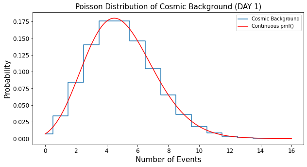

```python
plt.rcParams['figure.figsize'] = [10, 5]
# DAY 1
fig, ax = plt.subplots(1, 1)
ax.step(num_events, prob, where = 'mid', label = "Cosmic Background")
plt.title("Poisson Distribution of Cosmic Background (DAY 1)", size = 15)
plt.xlabel("Number of Events", size= 15)
plt.ylabel("Probability", size=15)

mu = X
def f(x):
   return np.exp(-mu)*(mu**x)/(scipy.special.factorial(x)) # Poisson distribution (the actual function)
x = np.linspace(0, 16, 1000)
ax.plot(x, f(x), color='red', label="Continuous pmf()")
plt.xticks(fontsize = 12)
plt.yticks(fontsize = 12)
plt.legend(loc="best")

plt.show()
```

#### Day 1 (semi-log)

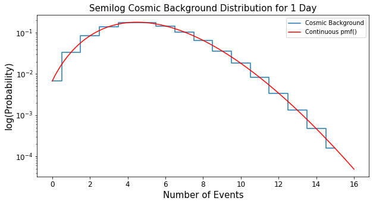

```python
plt.rcParams['figure.figsize'] = [10, 5]
# DAY 1
fig, ax = plt.subplots(1, 1)
ax.step(num_events, prob, where = 'mid', label = "Cosmic Background")
plt.yscale('log')
plt.title("Semilog Cosmic Background Distribution for 1 Day", size = 15)
plt.xlabel("Number of Events", size= 15)
plt.ylabel("log(Probability)", size=15)


mu = X
def f(x):
   return np.exp(-mu)*(mu**x)/(scipy.special.factorial(x)) # Poisson distribution (the actual function)
x = np.linspace(0, 16, 1000)
ax.plot(x, f(x), color='red', label="Continuous pmf()")
plt.xticks(fontsize = 12)
plt.yticks(fontsize = 12)
plt.legend(loc="best")
plt.show()
```

#### Day 2 (one day is added)

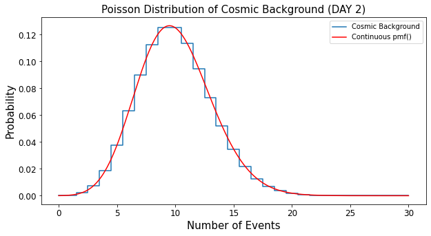

```python
# day 2 (one day being added)

# convolve background (Poisson distribution) once with itself
background_day_2 = np.convolve(prob, prob, mode='full')
num_events2 = np.arange(0, 31)

plt.rcParams['figure.figsize'] = [10, 5]
fig, ax = plt.subplots(1, 1)
ax.step(num_events2, background_day_2, where = 'mid', label = "Cosmic Background")
plt.title("Poisson Distribution of Cosmic Background (DAY 2)", size = 15)
plt.xlabel("Number of Events", size= 15)
plt.ylabel("Probability", size=15)


mu = 10 # because the day has advanced, average has increased (sum of two)
def f(x):
   return np.exp(-mu)*(mu**x)/(scipy.special.factorial(x)) # Poisson distribution (the actual function)
x = np.linspace(0, 30, 1000)

ax.plot(x, f(x), color='red', label="Continuous pmf()")
plt.xticks(fontsize = 12)
plt.yticks(fontsize = 12)
plt.legend(loc="best")
plt.show()
```

#### Day 2 (one day is added, semilog)

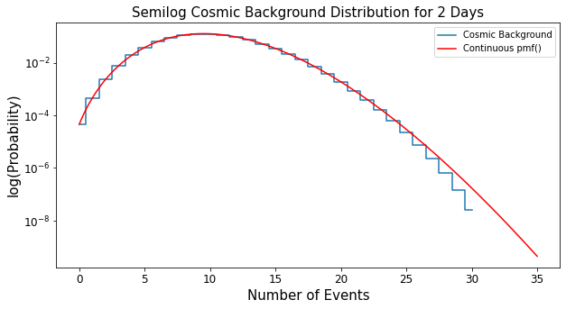

```python
# day 2 (one day being added, semilog)

# convolve background (Poisson distribution) once with itself
plt.rcParams['figure.figsize'] = [10, 5]
fig, ax = plt.subplots(1, 1)
plt.yscale('log')
ax.step(num_events2, background_day_2, where = 'mid', label = "Cosmic Background")
plt.title("Semilog Cosmic Background Distribution for 2 Days", size = 15)
plt.xlabel("Number of Events", size= 15)
plt.ylabel("log(Probability)", size=15)

mu = 10 # because the day has advanced, average has increased (sum of two)
def f(x):
   return np.exp(-mu)*(mu**x)/(scipy.special.factorial(x)) # Poisson distribution (the actual function)
x = np.linspace(0, 35, 1000)

ax.plot(x, f(x), color='red', label="Continuous pmf()")
plt.xticks(fontsize = 12)
plt.yticks(fontsize = 12)
plt.legend(loc="best")
plt.show()
```

#### Day 3 (one day is added)

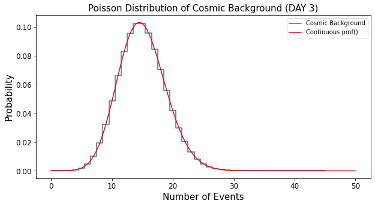

```python
# day 3 (one day being added)

# convolved background (Poisson distribution) once again
background_day_3 = np.convolve(background_day_2, prob, mode='full')
num_events2 = np.arange(0, 46)


plt.rcParams['figure.figsize'] = [10, 5]
fig, ax = plt.subplots(1, 1)
ax.step(num_events2, background_day_3, where = 'mid', label = "Cosmic Background")
plt.title("Poisson Distribution of Cosmic Background (DAY 3)", size = 15)
plt.xlabel("Number of Events", size= 15)
plt.ylabel("Probability", size=15)

mu = 15 # because the day has advanced, average has increased (sum of two)
def f(x):
   return np.exp(-mu)*(mu**x)/(scipy.special.factorial(x)) # Poisson distribution (the actual function)
x = np.linspace(0, 50, 1000)

ax.plot(x, f(x), color='red', label="Continuous pmf()")
plt.xticks(fontsize = 12)
plt.yticks(fontsize = 12)
plt.legend(loc="best")
plt.show()
```

#### Day 3 (one day is added, semilog)

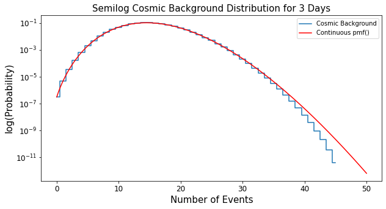

```python
# day 3 (one day being added, semilog)
plt.rcParams['figure.figsize'] = [10, 5]
fig, ax = plt.subplots(1, 1)
plt.yscale('log')
ax.step(num_events2, background_day_3, where = 'mid', label = "Cosmic Background")
plt.title("Semilog Cosmic Background Distribution for 3 Days", size = 15)
plt.xlabel("Number of Events", size= 15)
plt.ylabel("log(Probability)", size=15)

mu = 15 # because the day has advanced, average has increased (sum of 3)
def f(x):
   return np.exp(-mu)*(mu**x)/(scipy.special.factorial(x)) # Poisson distribution (the actual function)
x = np.linspace(0, 50, 1000)

ax.plot(x, f(x), color='red', label="Continuous pmf()")
plt.xticks(fontsize = 12)
plt.yticks(fontsize = 12)
plt.legend(loc="best")
plt.show()
```

#### Day 4 (one day is added)

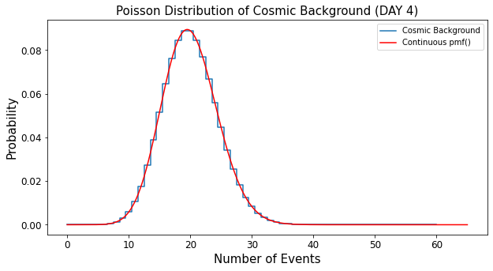

```python
# day 4 (one day being added)

# convolved background (Poisson distribution) once again
background_day_4 = np.convolve(background_day_3, prob, mode='full')
num_events2 = np.arange(0, 61)


plt.rcParams['figure.figsize'] = [10, 5]
fig, ax = plt.subplots(1, 1)
ax.step(num_events2, background_day_4, where = 'mid', label = "Cosmic Background")
plt.title("Poisson Distribution of Cosmic Background (DAY 4)", size = 15)
plt.xlabel("Number of Events", size= 15)
plt.ylabel("Probability", size=15)

mu = 20 # because the day has advanced, average has increased (sum of 4)
def f(x):
   return np.exp(-mu)*(mu**x)/(scipy.special.factorial(x)) # Poisson distribution (the actual function)
x = np.linspace(0, 65, 1000)

ax.plot(x, f(x), color='red', label="Continuous pmf()")
plt.xticks(fontsize = 12)
plt.yticks(fontsize = 12)
plt.legend(loc="best")
plt.show()
```

#### Day 4 (one day is added, semilog)

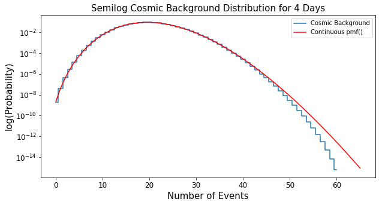

```python
# day 4 (one day being added (semi-log))

plt.rcParams['figure.figsize'] = [10, 5]
fig, ax = plt.subplots(1, 1)
plt.yscale('log')
ax.step(num_events2, background_day_4, where = 'mid', label = "Cosmic Background")
plt.title("Semilog Cosmic Background Distribution for 4 Days", size = 15)
plt.xlabel("Number of Events", size= 15)
plt.ylabel("log(Probability)", size=15)

mu = 20 # because the day has advanced, average has increased (sum of 4)
def f(x):
   return np.exp(-mu)*(mu**x)/(scipy.special.factorial(x)) # Poisson distribution (the actual function)
x = np.linspace(0, 65, 1000)

ax.plot(x, f(x), color='red', label="Continuous pmf()")
plt.xticks(fontsize = 12)
plt.yticks(fontsize = 12)
plt.legend(loc="best")
plt.show()
```

### Part B

Show that after 5 days, the summed probability distribution is still a Poisson distribution

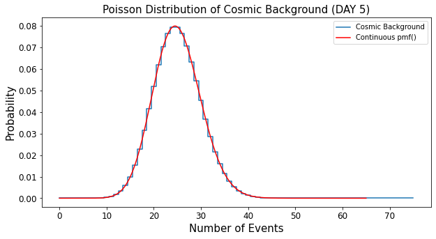

```python
# day 5 (one day being added)

# convolved background (Poisson distribution) once again
background_day_5 = np.convolve(background_day_4, prob, mode='full')
num_events2 = np.arange(0, 76)


plt.rcParams['figure.figsize'] = [10, 5]
fig, ax = plt.subplots(1, 1)
ax.step(num_events2, background_day_5, where = 'mid', label = "Cosmic Background")
plt.title("Poisson Distribution of Cosmic Background (DAY 5)", size = 15)
plt.xlabel("Number of Events", size= 15)
plt.ylabel("Probability", size=15)

mu = 25 # because the day has advanced, average has increased (sum of 5)
def f(x):
   return np.exp(-mu)*(mu**x)/(scipy.special.factorial(x)) # Poisson distribution (the actual function)
x = np.linspace(0, 65, 1000)

ax.plot(x, f(x), color='red', label="Continuous pmf()")
plt.xticks(fontsize = 12)
plt.yticks(fontsize = 12)
plt.legend(loc="best")
plt.show()
```

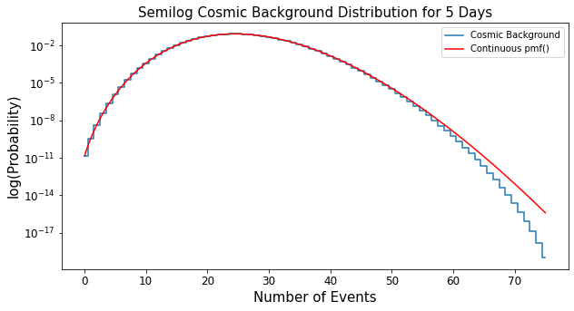

```python
# day 5 (one day being added, semilog)

plt.rcParams['figure.figsize'] = [10, 5]
fig, ax = plt.subplots(1, 1)
plt.yscale('log')
ax.step(num_events2, background_day_5, where = 'mid', label = "Cosmic Background")
plt.title("Semilog Cosmic Background Distribution for 5 Days", size = 15)
plt.xlabel("Number of Events", size= 15)
plt.ylabel("log(Probability)", size=15)

mu = 25 # because the day has advanced, average has increased (sum of 5)
def f(x):
   return np.exp(-mu)*(mu**x)/(scipy.special.factorial(x)) # Poisson distribution (the actual function)
x = np.linspace(0, 75, 1000)

ax.plot(x, f(x), color='red', label="Continuous pmf()")
plt.xticks(fontsize = 12)
plt.yticks(fontsize = 12)
plt.legend(loc="best")
plt.show()
```